# root_stem_crown_comparison

Aaron Yerke

This the R Notebook for collaboration with Dr. Yogini Jaiswal for her comparison of roots, stems, and crowns.

From Yogini: I. Changes done in all files and annotations * In all the files refer to the sheet: “Combined stem and roots” and “For PCA – Stem and Roots” * All cells in pink indicate that the constituent is not present in the sample * I believe in the previous study, we used “zeros” in rows where samples were not present. * All values present in “Combined stem and roots” are normalised with internal standard area for GC-MS File. * The data generated for analytes represent relative rather than absolute concentrations (semi-quantitative) based on their areas. All values generated for these compounds are therefore “unitless” but strongly correlate to absolute concentration when comparing values for the same metabolite; however, this does not apply when comparing values between different metabos. * For LC-MS analysis there are two files, negative and positive representing 2 different modes of ionisation used for analysis to have a more comprehensive identification of compounds that can be detected/ionised in both positive and negative mode. * There can be compounds that may be common between both ‘positive’ and ‘negative’ mode of LC-MS analysis files.

2. Nomenclature: A. Crown root parts: CRP: Crown root peel. CNP: Crown root with ‘no’ peel CWP: Whole crown root B. Lateral root parts: LRP: whole lateral root C. Stem parts: SWP: Whole stem. SNP: Stem with ‘no’ peel SP: Stem peel

III.A Suggested comparisons by Dr. Jaiswal with Aaron’s Notes 1. Whole crown root / lateral root/ stem Cycle through all of the metabolites and do ALL the metadata catagories lme(metabo ~ metad, method= “REML”, random = ~1 | plant_number, data = myD) then anova

```
table showing pvals for each test for each metabolite
  metabo test1 test2 test3 ...
```

2. Each part of Crown root and lateral root. lme with random effects of sample number
3. Each part of Crown root 3 Samples each with 3 sections: CRP, CNP, CWO lme with random effect on sample number ANOVA

III.B Additional tests suggested by Aaron 1. Comparison of each metabolite to the top three mds axis Add Pval for plant_num to show this isn’t a batch effect

2. Comparison of each metadata to the top three mds axis

IV. Changes done in files for PCA analysis:

File 1: NCAT155_GCMS_7July2017 (1) 1. Refer to the sheet: “Combined stem and roots” and “For PCA – Stem and Roots”. 2. Removed the internal standard row - “Docosanoic acid, methyl ester (IS)”, as it is an internal standard used for quality control and not a constituent. 3. Removed putative annotations for “present” and “not present”

File 2: NCAT155-Negative mode - LC-MS 1. Refer to the sheet: “Combined stem and roots” and “For PCA – Stem and Roots”. 2. In this file, all samples marked in green, are the same constituent but different mass adducts. So I have discarded them in the sheet “For PCA – Stem and Roots”.

File 3: NCAT155-Positive mode- LC-MS-SORTED- Roots 1. Refer to the sheet: “Combined stem and roots” and “For PCA – Stem and Roots”. 2. In this file, all samples marked in green, are the same constituent but different mass adducts. So I have discarded them in the sheet “For PCA – Stem and Roots”.  
3. For compounds with two adducts, the adduct rows with lower areas are deleted (will check with you before deletion)

Bioactive compounds: Kavain Dihydromethysticin Desmethoxyyangonin

Metadata categories for publication: tissue plant part plant number

First load the data:

```r
rm(list = ls()) #clear workspace
#declare dataset
ds = 'gc'
#read in meta-data
metadata = read.table(file.path('.','gc','meta_data.csv'),
  sep=",",
  header=TRUE,
  row.names = 1,
  check.names = FALSE,
  stringsAsFactors=FALSE)
#read in raw numeric data
metabolites = read.table(file.path('.', ds,'gc_data_numeric.csv'),
  sep=",",
  header=TRUE,
  row.names = 1,
  check.names = FALSE)
if (!require("RColorBrewer")) {
install.packages("RColorBrewer")
library(RColorBrewer)
}
#set color palette
palette( brewer.pal(7,"Accent") )
dim(metabolites)
```

```
[1] 29 21
```

```r
#boxplot before transform
boxplot(metabolites,
  main = paste(toupper(ds), 'Data without log-transform'),
  col = as.factor(metadata['tissue',]),
  xlab = "tissues",
  xaxt = 'n'
)
mtext(text= unique(as.factor(metadata['tissue',])),
  side = 1,
  outer = FALSE,
  at = seq(2, 21, by = 3),
  line = 1
  )
```

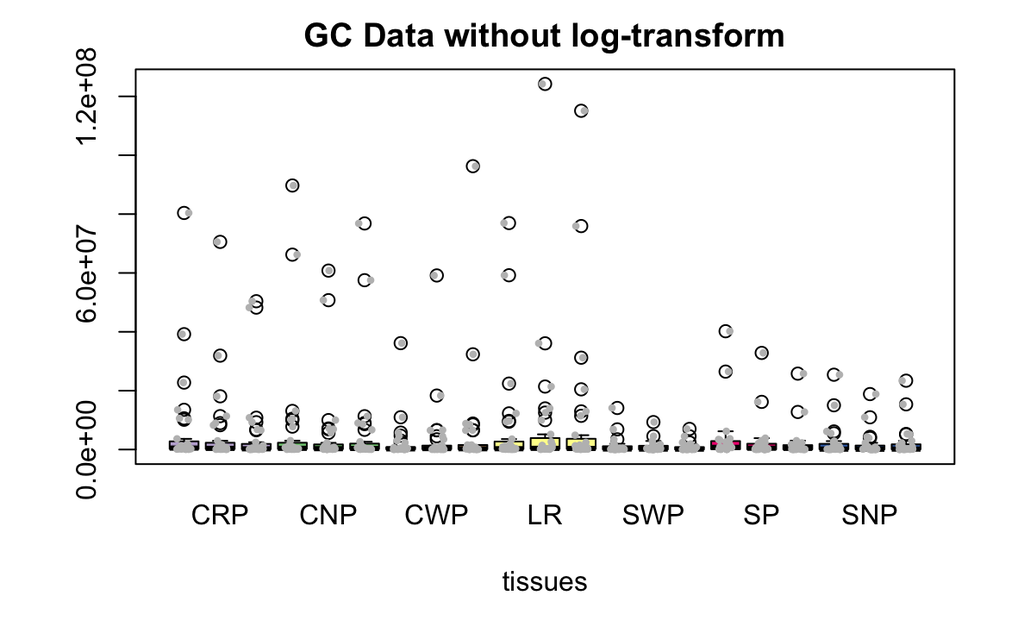

```r
par(new=TRUE)
stripchart(metabolites,
  method='jitter',
  jitter=.2,
  vertical=TRUE,
  add=T,
  pch=16,
  cex = 0.6,
  col = 'grey'
  )
```

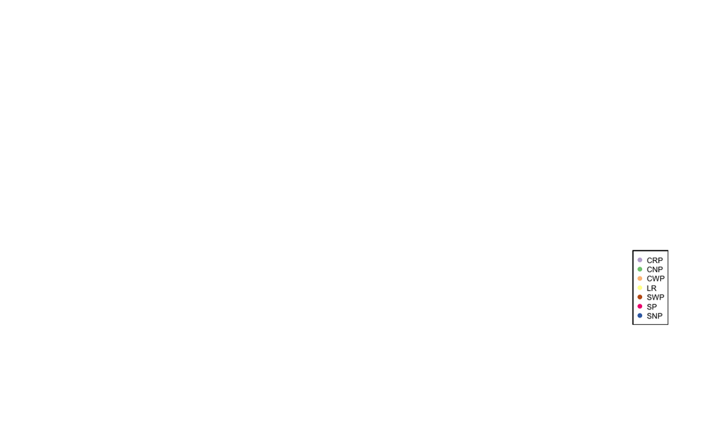

```r
plot.new()
legend('bottomright',
  legend = unique(as.factor(metadata['tissue',])),
  col = unique(as.factor(metadata['tissue',])),
  pch = 19,
  cex=0.4
  )
```

This plot is hard to see. Let’s try log transform..

```r
metabolites = log2(metabolites + 1)
```

```r
par(bty = 'l',
    mar = c(5, 4, 5, 2) + 0.1)
boxplot(metabolites,
  main = paste(toupper(ds), 'Data with log-transform'),
  col = as.factor(metadata['tissue',]),
  xlab = "tissues",
  xaxt = 'n'
)
mtext(text= unique(as.factor(metadata['tissue',])),
  side = 1,
  outer = FALSE,
  at = seq(2, 21, by = 3),
  line = 1
  )
```

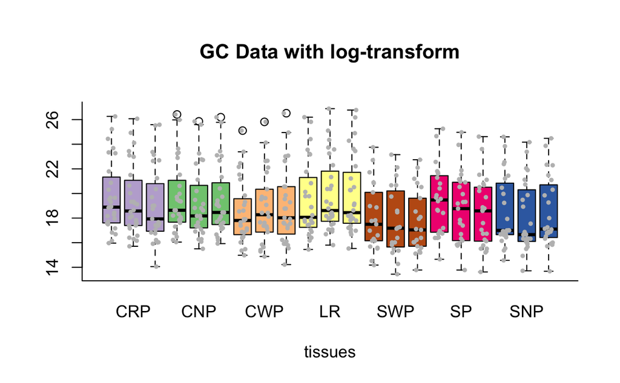

```r
par(new=TRUE)
stripchart(metabolites,
  method='jitter',
  jitter=.2,
  vertical=TRUE,
  add=T,
  pch=16,
  cex = 0.6,
  col = 'grey'
  )
```

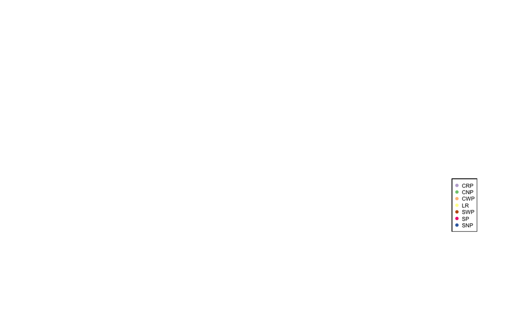

```r
plot.new()
legend('bottomright',
  legend = unique(as.factor(metadata['tissue',])),
  col = unique(as.factor(metadata['tissue',])),
  pch = 19,
  cex=0.4
  )
```

This tells me that we need to use the log transform.

To make publication size pdf:

```r
pdf(paste(ds, "OverallBoxplot.pdf", sep=""), width = 5, height = 4)
  par(bty = 'l',
    mar = c(5, 4, 5, 2) + 0.1)
boxplot(metabolites,
  main = paste(toupper(ds), 'Data with log-transform'),
  col = as.factor(metadata['tissue',]),
  xlab = "tissues",
  xaxt = 'n'
)
#  axis(side = 2, seq(14,26,2)) figure this out later
mtext(text= unique(as.factor(metadata['tissue',])),
  side = 1,
  outer = FALSE,
  at = seq(2, 21, by = 3),
  line = 1
  )
par(new=TRUE)
stripchart(metabolites,
  method='jitter',
  jitter=.2,
  vertical=TRUE,
  add=T,
  pch=16,
  cex = 0.6,
  col = 'grey'
  )
plot.new()
```

```r
legend('bottomright',
  legend = unique(as.factor(metadata['tissue',])),
  col = unique(as.factor(metadata['tissue',])),
  pch = 19,
  cex=0.4
  )
dev.off()
```

Next look at PCA.

```r
#create PCA
group_pca = prcomp(t(na.omit(metabolites)),
  center = TRUE,
  scale = TRUE)
#extract PCA matrix and convert to dataframe
myPCA = data.frame(group_pca$x)
summary(group_pca)
```

```
Importance of components:
                          PC1    PC2     PC3     PC4     PC5     PC6
Standard deviation     3.7669 1.6860 0.89073 0.66735 0.63049 0.42767
Proportion of Variance 0.7468 0.1496 0.04176 0.02344 0.02092 0.00963
Cumulative Proportion  0.7468 0.8964 0.93818 0.96162 0.98255 0.99217
                          PC7     PC8     PC9    PC10    PC11    PC12
Standard deviation     0.2348 0.20585 0.14575 0.11673 0.10219 0.05519
Proportion of Variance 0.0029 0.00223 0.00112 0.00072 0.00055 0.00016
Cumulative Proportion  0.9951 0.99730 0.99842 0.99914 0.99969 0.99985
                          PC13    PC14    PC15    PC16     PC17
Standard deviation     0.03695 0.03183 0.01911 0.00979 0.003925
Proportion of Variance 0.00007 0.00005 0.00002 0.00001 0.000000
Cumulative Proportion  0.99992 0.99997 0.99999 1.00000 1.000000
                          PC18      PC19
Standard deviation     0.00299 4.356e-18
Proportion of Variance 0.00000 0.000e+00
Cumulative Proportion  1.00000 1.000e+00
```

PCA1 and PCA2

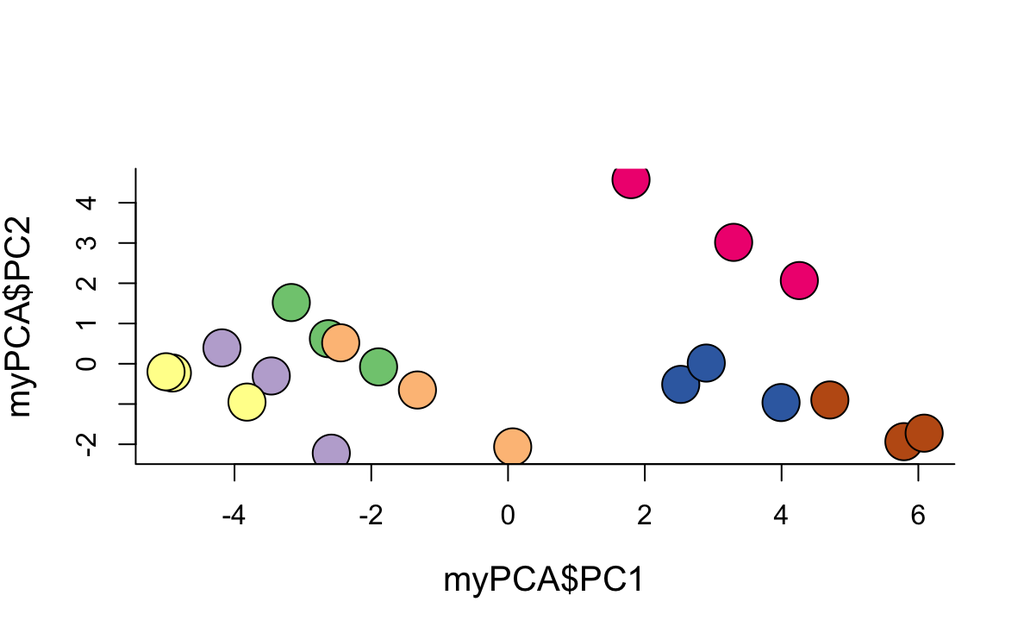

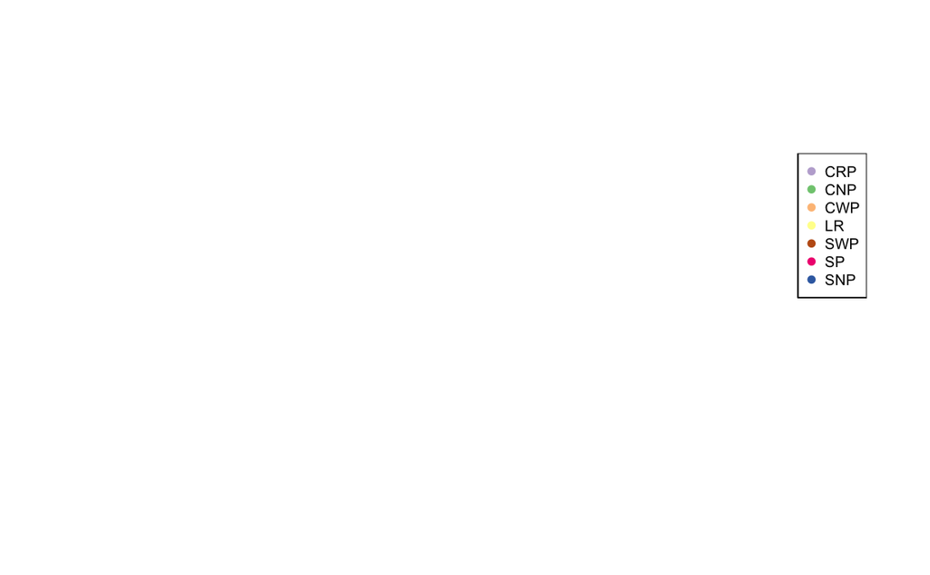

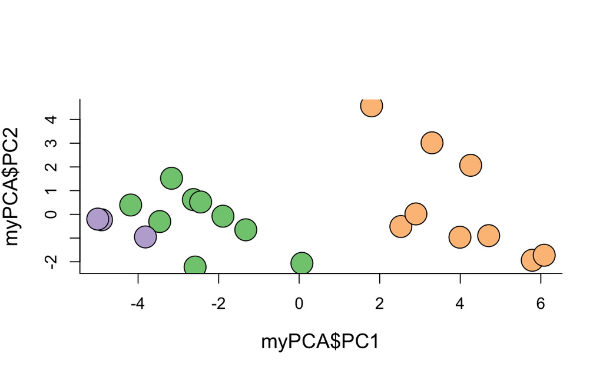

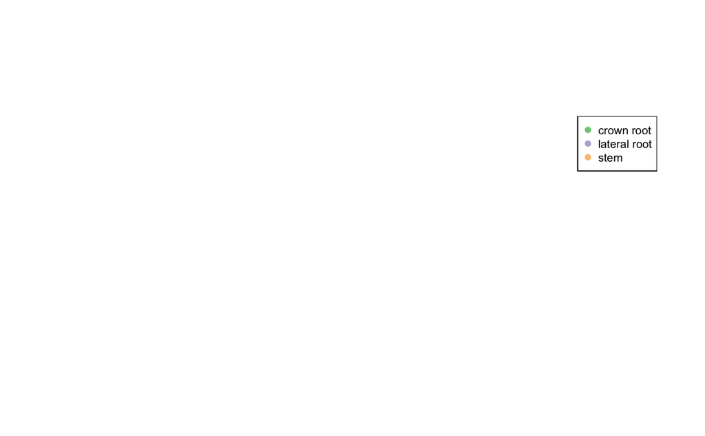

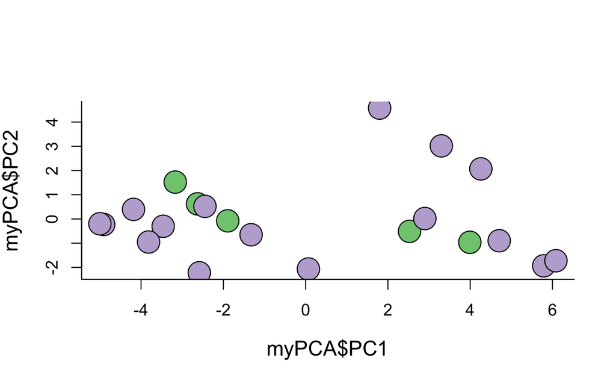

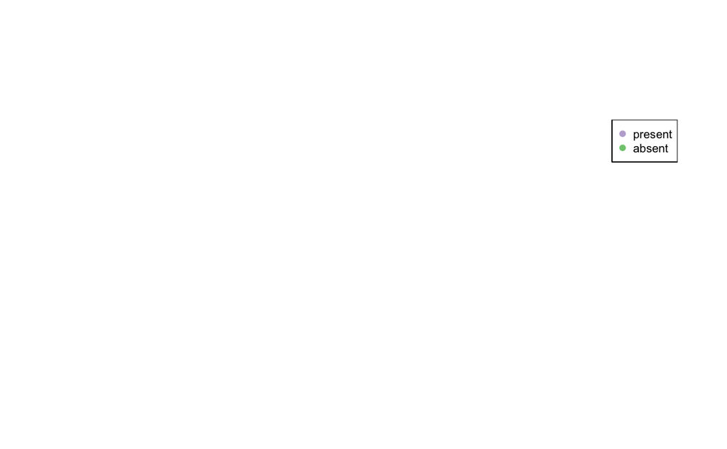

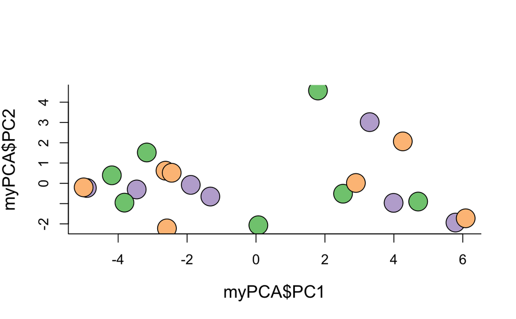

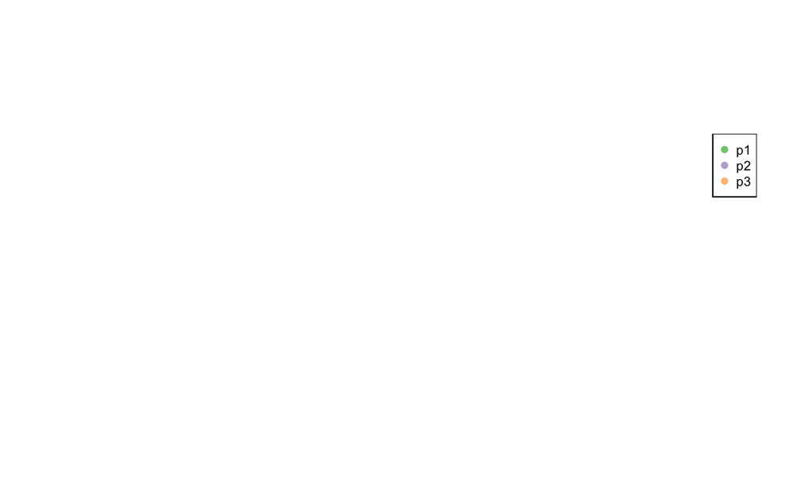

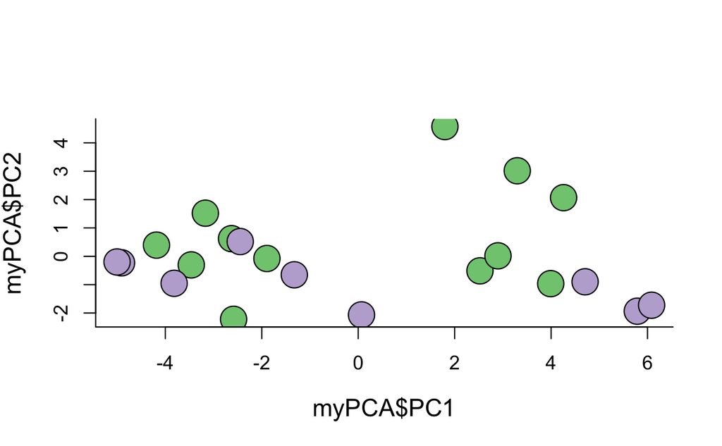

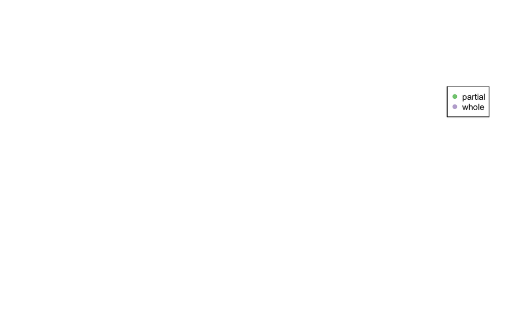

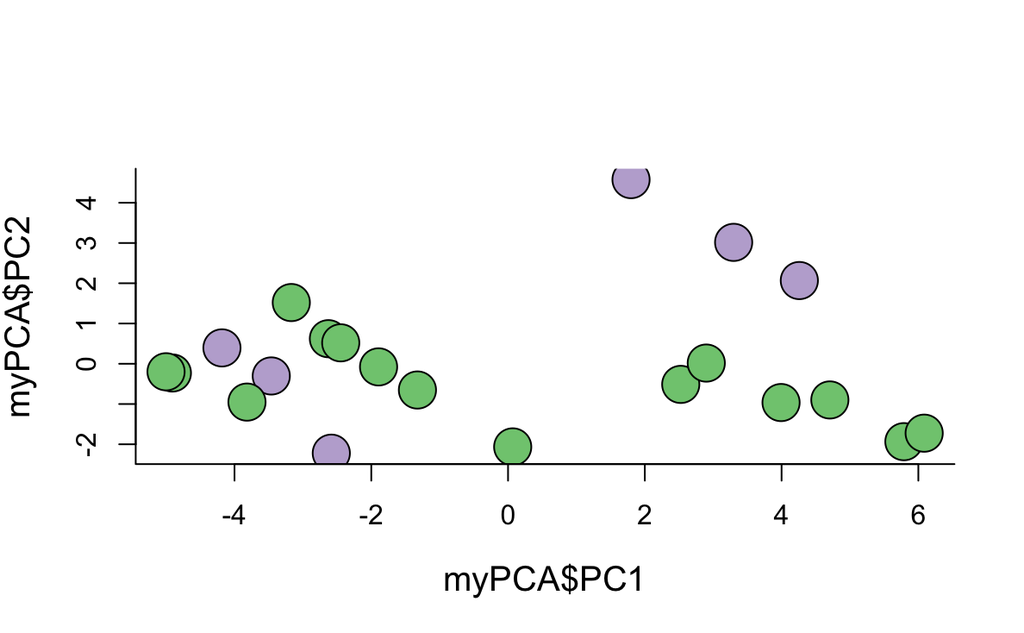

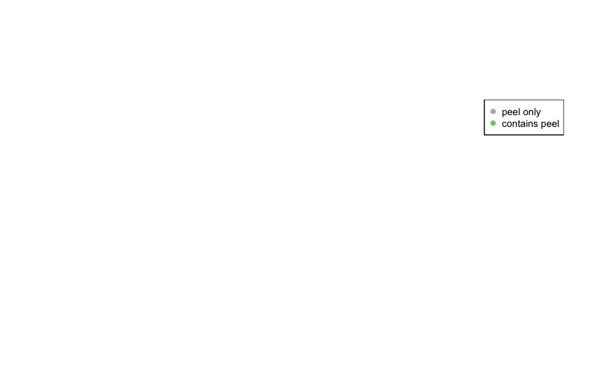

[2 more figures not shown]

```r
for (i in 1:nrow(metadata)){
  par(bty = 'l',
    mar = c(5, 4, 5, 2) + 0.1,
    cex.lab = 1.25
    )
  plot(myPCA$PC1, myPCA$PC2,
    col='black',
    pch = 21,
    bg = as.factor(metadata[i,]),
    cex = 3
  )
  plot.new()
  legend('topright', legend = unique(as.factor(metadata[i,])),
    col = unique(as.factor(unique(metadata[i,]))),
    pch = 19,
    cex=0.6
    )
}
```